# Global Neonatal Mortality: 30-Year Trends and 2023 Geographic Extremes

This analysis uses UNICEF data to explore how neonatal mortality patterns have changed over time and across countries. The goal is to understand long-term trends, identify country-level extremes, and evaluate progress made between 1990 and 2023.

## Introduction

Neonatal mortality remains one of the most important global health challenges. While overall child mortality has declined over recent decades, deaths occurring during the first 28 days of life continue to represent a major share of total child deaths.

This dashboard focuses on three key areas:

- **Long-term trends** in mortality from 1990 to 2023
- **Country-level differences** in mortality rates
- **Progress tracking** between 1990 and 2023

Understanding these patterns helps identify where healthcare systems need the most improvement.

## Country-Level Extremes in 2023

The bar chart below compares the **Top 10 and Bottom 10 countries** based on neonatal mortality values in 2023.

This comparison helps identify regions that require targeted healthcare investment.

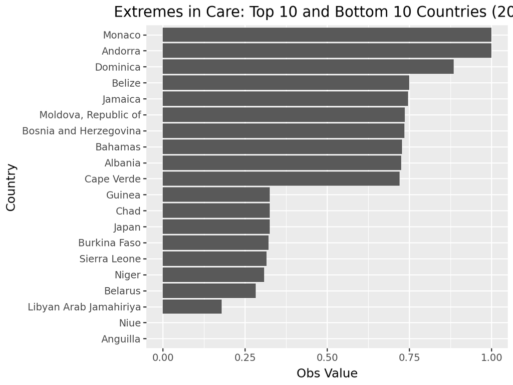

## Tracking Progress Between 1990 and 2023

The scatterplot below compares country-level mortality values between **1990 and 2023**.

This visualization helps evaluate how different countries have progressed over the last three decades.

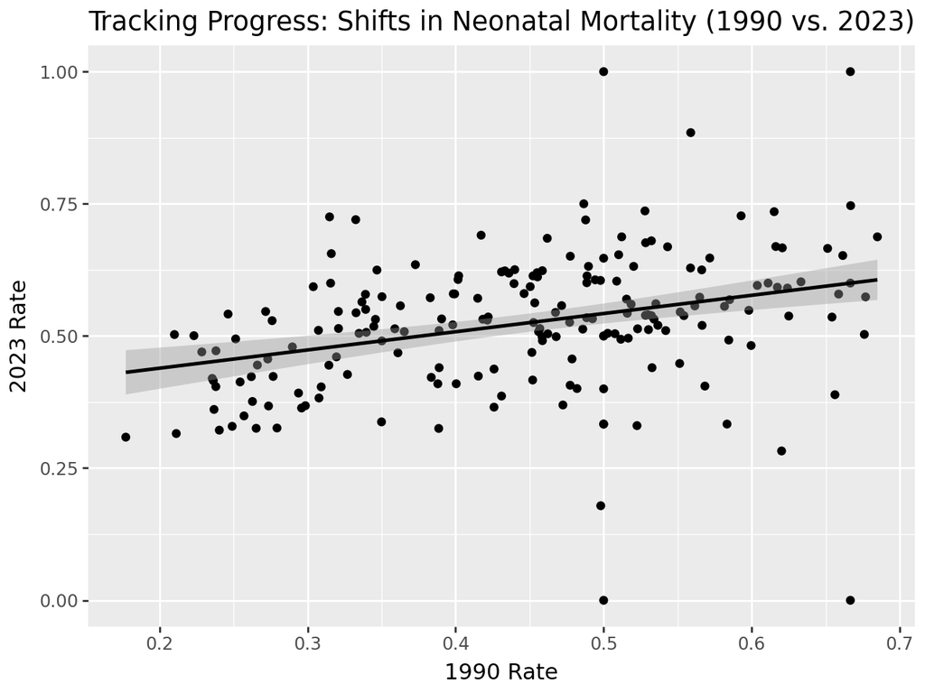

## Trend Analysis: Changes Over Time

The line chart below shows how neonatal mortality values have changed between **1990 and 2023**.

Key observations include:

- A steady shift in mortality patterns over time
- Improvements in healthcare reducing overall child mortality
- Neonatal mortality remaining an important component of total deaths

This trend highlights the need for continued focus on maternal and newborn healthcare services.

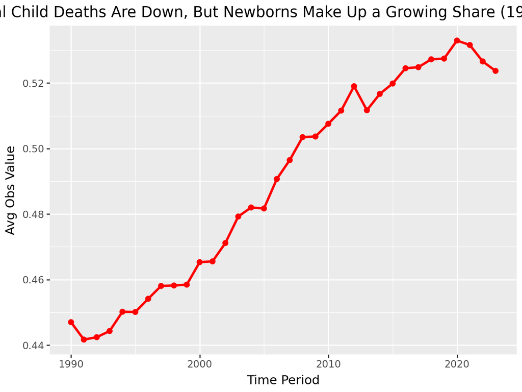

## Global Distribution of Neonatal Mortality Rates (2023)

The map below shows how neonatal mortality values differ across countries in 2023.

This visual helps identify where healthcare intervention and support may be needed most.

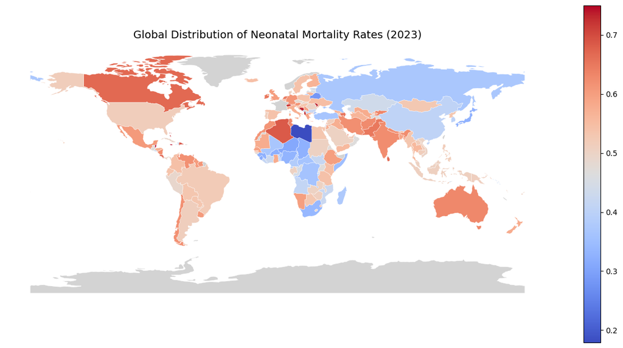

## Conclusion

This analysis shows that although child survival has improved over the last three decades, neonatal mortality remains a major global challenge.

The charts highlight that:

Overall, stronger maternal and newborn healthcare systems are essential to reduce these inequalities and improve global child health outcomes.

[output not shown]